# Simulations

Knit on

November 14, 2026

# 1 Setup

```r
library(conflicted)
library(tidyverse)
library(dagitty)
library(tidybayes)
library(distributional)
library(brms)
library(bayesplot)
library(DT)

source("functions.R")

conflicts_prefer(dplyr::filter,
                 tidyr::expand,
                 stats::lag,
                 distributional::parameters,
                 brms::ar,
                 brms::dstudent_t,
                 brms::pstudent_t,
                 brms::qstudent_t,
                 brms::rstudent_t,
                 brms::rhat)

options(mc.cores = parallel::detectCores())
options(brms.file_refit = "on_change")
#install.packages("cmdstanr", repos = c('https://stan-dev.r-universe.dev', getOption("repos")))
#check https://mc-stan.org/cmdstanr/
#install.packages('hexbin')

options(brms.backend = "cmdstanr")
options(brms.plot_points = T)
options(contrasts = c("contr.sum", "contr.poly"))
options(digits = 3)

if (!dir.exists("fits/sim")) dir.create("fits/sim", recursive = T)

theme_set(theme_minimal())
```

# 2 Test the model with simulated data

## 2.1 Create simulated data

The simulated data follows a generative model based on the DAG, with the same data structure of the actual data. Each site has a group mean of two weather variables (e.g. temperature, precipitation) and annual fluctuations. FD is related to temperature and precipitation. There are two unobserved confounds: U1, which is time-invariant, and U2, which is not. U1 affects weather means and FD. An average SES below zero can result, for example, from habitat filtering together with species turnover, an average SES above zero from limiting similarity or within-site heterogeneity together with species turnover. U2 is a common cause of temperature and precipitation, which means that omitting either variable would result in confounding. The data are generated according to this DAG:

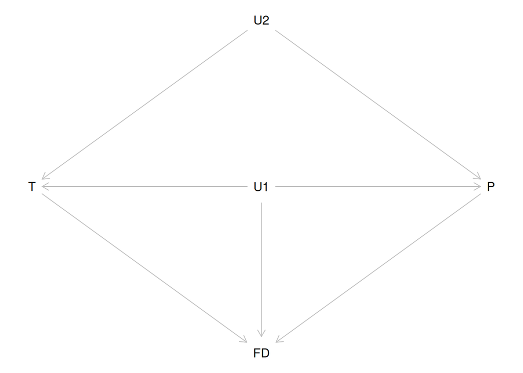

```r
set.seed(126)

#there are four sites
n_sites <- 4
#there are eight years
n_years <- 8

sites <- fct(LETTERS[1:n_sites])

years <- seq_len(n_years)

#sites have a different number of subplots, between 10 and 25
subplots <- sample(10:25, length(sites), replace = T)

sim <- tibble(site = rep(sites, times = subplots),
              subplot = sequence(subplots))

sim <- expand_grid(year = years, sim)

#parameters
#the confound has mean 0 and SD 1
u1_t <- 1 #effect of confound U1 on temperature
u1_p <- -1 #effect of confound U1 on precipitation
u1_y <-  1 #effect of confound U1 on outcome
u2_t <- 0.5 #effect of confound U2 on temperature
u2_p <- 0.5 #effect of confound U2 on precipitation
weat_sd <- 0.5 #within-site yearly weather SD
site_sd <- 1 #between-site variation
u1_sd <- 1 #SD of time-invariant confound
u2_sd <- 0.5 #SD of time-variant confound
residual <- 0.5 #residual variation between subplots

#simulation function
# t_y effect of temp on FD
# p_y effect of prec on FD
# int_w within-site interaction between temp and prec
# int_c1, int_c2 cross level interactions
# int_b site-level interaction

weat_sim <- function(x, t_y = 0, p_y = 0, int_w = 0, int_c1 = 0, int_c2 = 0, int_b = 0) {
  x |>
    #time-invariant components
    mutate(u1 = rnorm(1, mean = 0, sd = u1_sd), # unobserved time-invariant confound
           #site-level weather means
           t_site = rnorm(1, mean = u1_t * u1, sd = site_sd),
           p_site = rnorm(1, mean = u1_p * u1, sd = site_sd),
           .by = site) |>
    #each year has weather values, affected by the site means and the confounds
    mutate(u2 = rnorm(1, mean = 0, sd = u2_sd), # time-varying confound between T and P
           # within-site weather fluctuations
           temp_w = rnorm(1, mean = u2_t * u2, sd = weat_sd),
           prec_w = rnorm(1, mean = u2_p * u2, sd = weat_sd),
           temp = temp_w + t_site,
           prec = prec_w + p_site,
           .by = c(site, year)) |>
    #FD-SES outcome affected by weather and confounds
    mutate(FD = rnorm(n(), mean = t_y * temp +
                                  p_y * prec +
                                  int_w * temp_w * prec_w +
                                  int_c1 * temp_w * p_site +
                                  int_c2 * t_site * prec_w +
                                  int_b * t_site * p_site +
                                  u1_y * u1,
                      sd = residual)) |>
    #auxiliary variables
    mutate(t_mean = mean(temp),
           p_mean = mean(prec),
           t_cent = temp - t_mean,
           p_cent = prec - p_mean,
           t_x_p = t_cent * p_cent - mean(t_cent * p_cent),
           .by = site)
}
```

## 2.2 Models without interaction

Three scenarios represent an increase, decrease or no change in FD-SES with a within-site increase in temperature, while the effect of precipitation is always negative.

### 2.2.1 Positive effect

Both temperature and confound have a positive effect of FD:

```r
set.seed(20)

sim_pos <- sim |>
  weat_sim(t_y = 1, p_y = -0.5)

sim_pos |>
  ggplot(aes(x = site, y = temp, fill = site))+
  geom_boxplot()
```

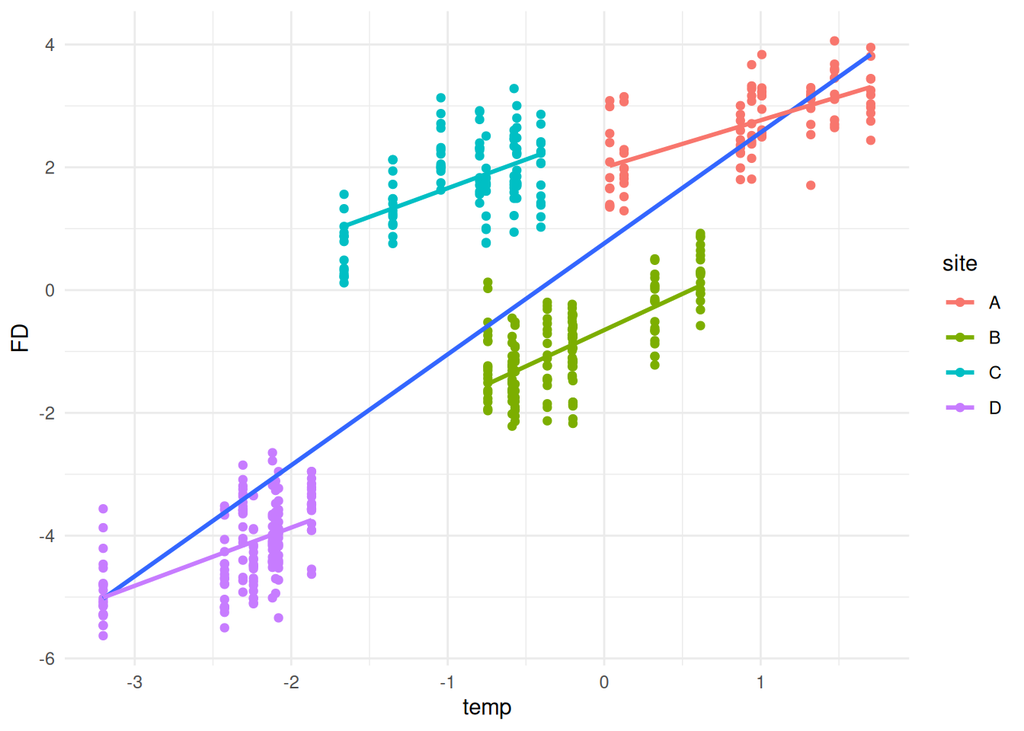

```r
sim_pos |>
  ggplot(aes(x = temp, y = FD))+
  geom_point(aes(color = site))+
  geom_smooth(method = "lm", se = F)+
  geom_smooth(aes(color = site),method = "lm", se = F)
```

### 2.2.2 Zero effect

In the second, the estimated effect is 0, there is only confounding:

```r
set.seed(20)

sim_nul <- sim |>
  weat_sim(t_y = 0, p_y = -0.5)

sim_nul |>
  ggplot(aes(x = site, y = temp, fill = site))+
  geom_boxplot()
```

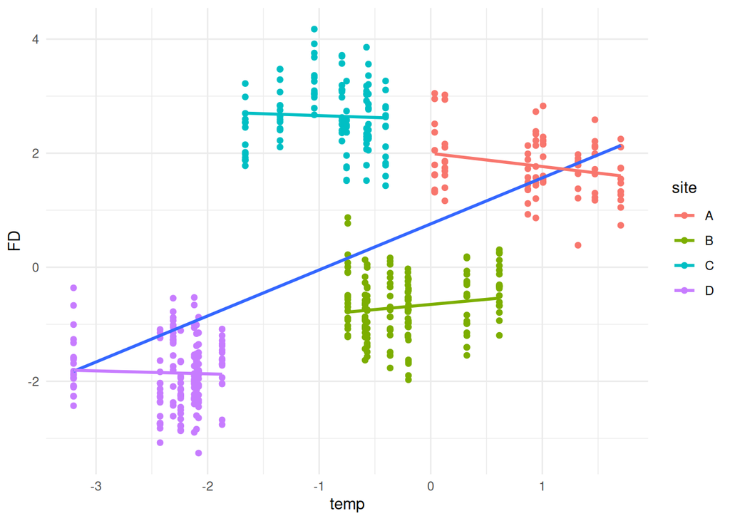

```r
sim_nul |>
  ggplot(aes(x = temp, y = FD))+
  geom_point(aes(color = site))+
  geom_smooth(method = "lm", se = F)+
  geom_smooth(aes(color = site),method = "lm", se = F)
```

### 2.2.3 Negative effect

In the third, the estimated effect is -1, contrasting the confound:

```r
set.seed(20)

sim_neg <- sim |>
  weat_sim(t_y = -1, p_y = -0.5)

sim_neg |>
  ggplot(aes(x = site, y = temp, fill = site))+
  geom_boxplot()
```

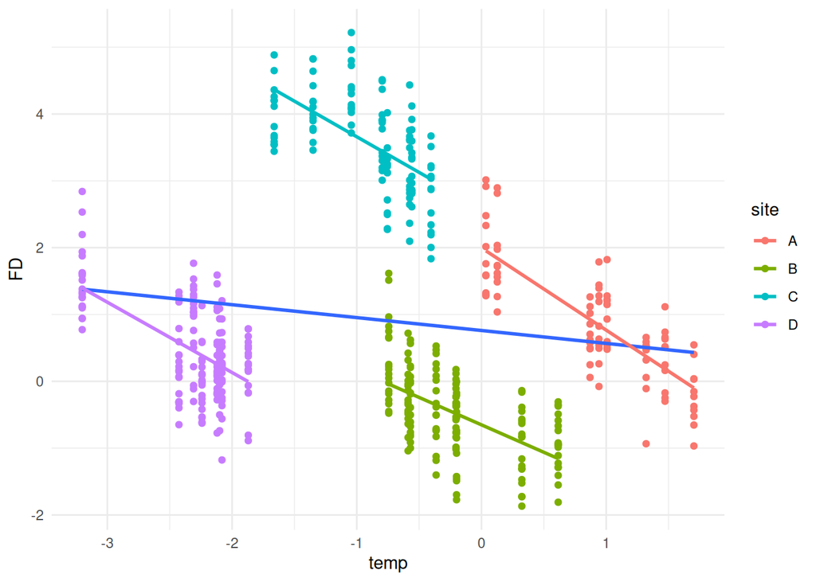

```r
sim_neg |>
  ggplot(aes(x = temp, y = FD))+
  geom_point(aes(color = site))+
  geom_smooth(method = "lm", se = F)+
  geom_smooth(aes(color = site),method = "lm", se = F)
```

# 3 Prior choice

Default priors can be too wide, and the prior for $\beta$ is an improper flat prior. Let’s find more reasonable priors.

```r
default_prior(FD ~ t_cent + p_cent + site, data = sim_pos)
```

| prior | class | coef | group | resp | dpar | nlpar | lb | ub | tag | source |
| --- | --- | --- | --- | --- | --- | --- | --- | --- | --- | --- |
|  | b |  |  |  |  |  |  |  |  | default |
|  | b | p_cent |  |  |  |  |  |  |  | default |
|  | b | site1 |  |  |  |  |  |  |  | default |
|  | b | site2 |  |  |  |  |  |  |  | default |
|  | b | site3 |  |  |  |  |  |  |  | default |
|  | b | t_cent |  |  |  |  |  |  |  | default |
| student_t(3, -0.7, 4) | Intercept |  |  |  |  |  |  |  |  | default |
| student_t(3, 0, 4) | sigma |  |  |  |  |  | 0 |  |  | default |

## 3.1 Intercept

Brms defines the intercept as the value of the outcome with all predictors at their mean. This is *not* the “b_Intercept” shown in the model output, but rather the internal “Intercept” parameter. In this simulation it is zero, but we should allow variation while considering that FD-SES should be usually within (-2, 2). Let’s check a default prior:

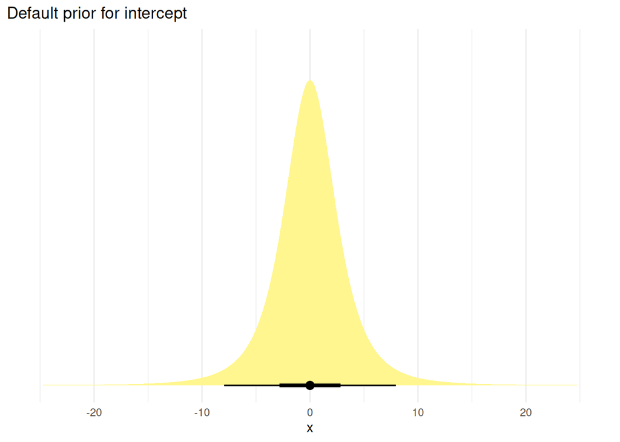

```r
ggplot()+
  stat_halfeye(aes(xdist = dist_student_t(3, 0, 2.5)),
    fill = "khaki1", .width = c(0.66, 0.95))+
  scale_y_continuous(NULL, breaks = NULL)+
  ggtitle("Default prior for intercept")
```

The overdispersion is worth keeping, but the prior is still too wide. Here’s a better prior:

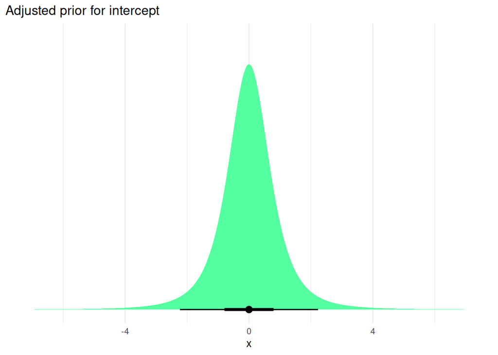

```r
ggplot()+
  stat_halfeye(aes(xdist = dist_student_t(3, 0, 0.7)),
    fill = "seagreen1", .width = c(0.66, 0.95))+
  scale_y_continuous(NULL, breaks = NULL)+
  ggtitle("Adjusted prior for intercept")
```

## 3.2 Beta coefficients

Large effects of weather on FD, but in this case also for the fixed effect of site, are unlikely. A weakly regularizing prior would still allow large effects, but most of the parameter probability is restricted to values closer to 0. The prior for $\beta$ in this simulation allows for effects twice as large as the true effects in any direction.

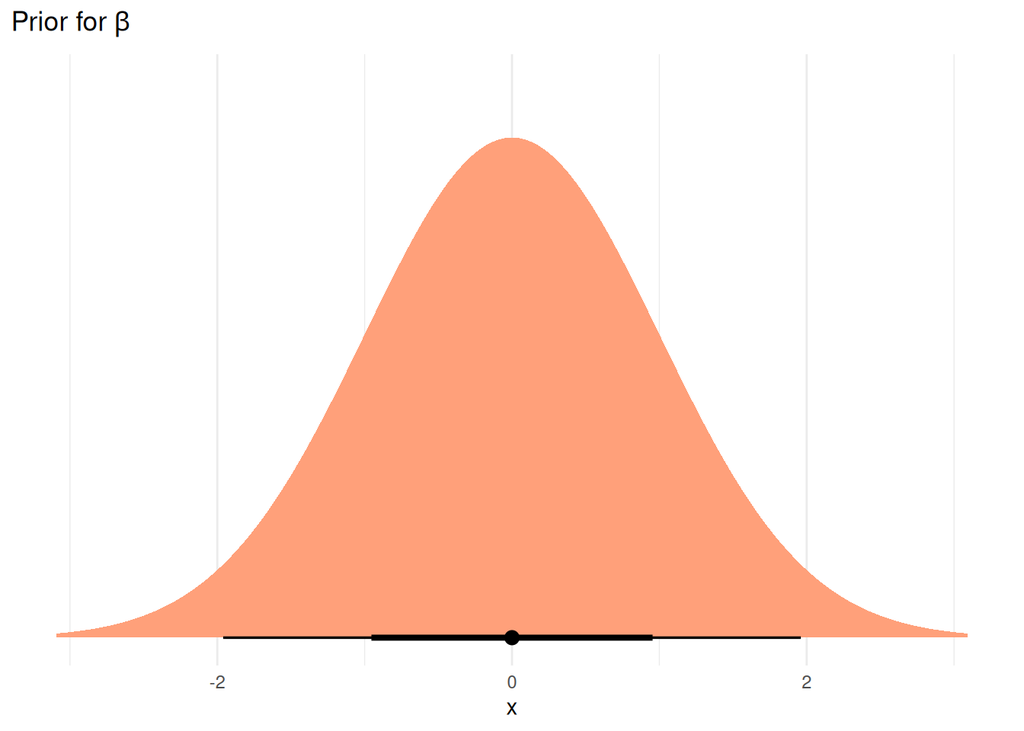

```r
ggplot()+
  stat_halfeye(aes(xdist = dist_normal(0, 1)),
    fill = "lightsalmon", .width = c(0.66, 0.95))+
  scale_y_continuous(NULL, breaks = NULL)+
  ggtitle(expression("Prior for"~beta))
```

## 3.3 Standard deviations

Next, the default prior for residual standard deviations is a half-t. This prior is evidently too flat, allowing variations higher than possible.

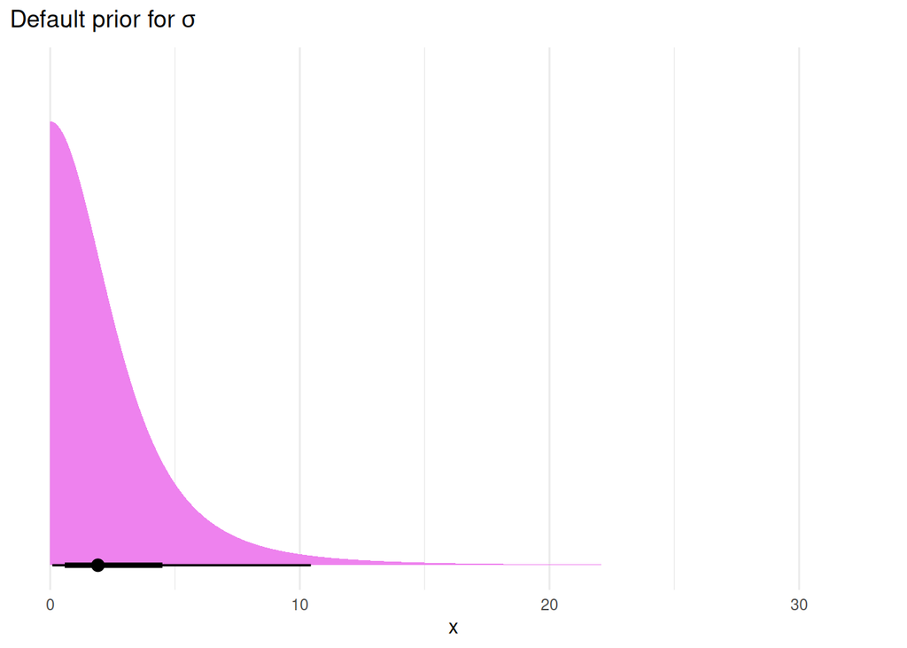

```r
ggplot()+
  stat_halfeye(aes(xdist = dist_truncated(dist_student_t(3, 0, 2.5), lower = 0)),
                fill = "violet", .width = c(0.66, 0.95))+
  scale_y_continuous(NULL, breaks = NULL)+
  ggtitle(expression("Default prior for"~sigma))
```

Here is instead, a more reasonable prior. Standard deviations of the outcome for residuals should be between 0 and 1, but higher values are allowed.

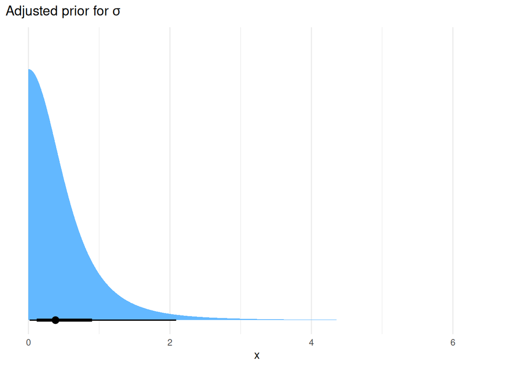

```r
ggplot()+
  stat_halfeye(aes(xdist = dist_truncated(dist_student_t(3, 0, 0.5), lower = 0)),
                fill = "steelblue1", .width = c(0.66, 0.95))+
  scale_y_continuous(NULL, breaks = NULL)+
  ggtitle(expression("Adjusted prior for"~sigma))
```

## 3.4 Storing the priors

```r
prior <- c(prior(student_t(3, 0, 0.7), class = "Intercept"),
           prior(normal(0, 1), class = "b"),
           prior(student_t(3, 0, 0.5), class = "sigma", lb = 0))
```

# 4 Plotting function

```r
#plots the posterior distribution of weather
coefplot <- function(x, vline, lims, pars = "b_temp"){
  mcmc_areas(x, pars = pars)+
  vline_at(vline, linetype = 2)+
  scale_x_continuous(limits = lims)+
  coord_cartesian(ylim = c(NA,1.05))
}
```

Intercept is an internal centered intercept, should not be shown together with b_Intercept https://discourse.mc-stan.org/t/b-intercept-and-intercept-how-are-they-related/12933. For diagnostics, the centered intercept is more useful, since the noncentered one is usually correlated with the slope.

```r
show <- vars(!c(lprior, lp__, b_Intercept))

hide <- c("lprior", "lp__", "b_Intercept")
```

# 5 Models without interactions

## 5.1 Confounded model ignoring site

```r
fit_conf_pos <- brm(FD ~ temp + prec,
                    data = sim_pos,
                    prior = prior,
                    file = "fits/sim/sim.conf.pos",
                    seed = 295)

fit_conf_pos
```

```
 Family: gaussian
  Links: mu = identity
Formula: FD ~ temp + prec
   Data: sim_pos (Number of observations: 512)
  Draws: 4 chains, each with iter = 2000; warmup = 1000; thin = 1;
         total post-warmup draws = 4000

Regression Coefficients:
          Estimate Est.Error l-95% CI u-95% CI Rhat Bulk_ESS Tail_ESS
Intercept    -0.16      0.04    -0.25    -0.08 1.00     3711     2928
temp          1.06      0.03     1.00     1.12 1.00     3586     2761
prec         -1.34      0.03    -1.40    -1.28 1.00     3766     2872

Further Distributional Parameters:
      Estimate Est.Error l-95% CI u-95% CI Rhat Bulk_ESS Tail_ESS
sigma     0.73      0.02     0.69     0.78 1.00     3832     2870

Draws were sampled using sample(hmc). For each parameter, Bulk_ESS
and Tail_ESS are effective sample size measures, and Rhat is the potential
scale reduction factor on split chains (at convergence, Rhat = 1).
```

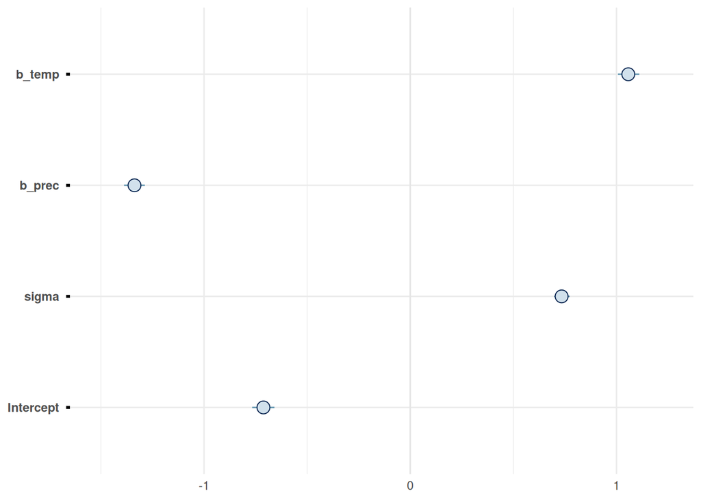

```r
mcmc_intervals(fit_conf_pos, pars = show)
```

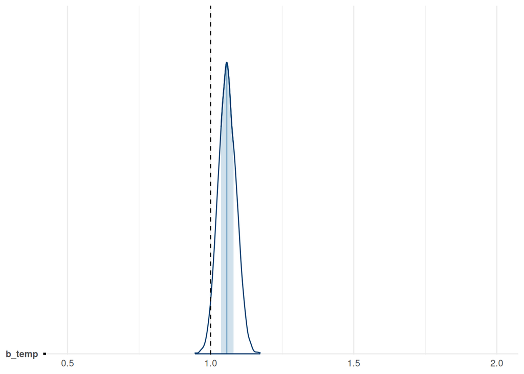

```r
fit_conf_pos |>
  coefplot(1, c(0.5, 2))
```

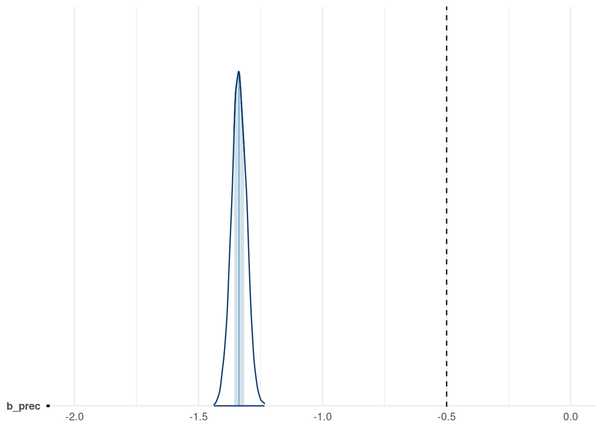

```r
fit_conf_pos |>
  coefplot(-0.5, c(-2, 0), pars = "b_prec")
```

```r
fit_conf_nul <- update(fit_conf_pos,
                       newdata = sim_nul,
                       file = "fits/sim/sim.conf.nul",
                       seed = 295)

fit_conf_nul
```

```
 Family: gaussian
  Links: mu = identity
Formula: FD ~ temp + prec
   Data: sim_nul (Number of observations: 512)
  Draws: 4 chains, each with iter = 2000; warmup = 1000; thin = 1;
         total post-warmup draws = 4000

Regression Coefficients:
          Estimate Est.Error l-95% CI u-95% CI Rhat Bulk_ESS Tail_ESS
Intercept    -0.16      0.04    -0.25    -0.08 1.00     3274     2968
temp          0.06      0.03    -0.01     0.12 1.00     3135     2839
prec         -1.34      0.03    -1.39    -1.28 1.00     3341     2474

Further Distributional Parameters:
      Estimate Est.Error l-95% CI u-95% CI Rhat Bulk_ESS Tail_ESS
sigma     0.73      0.02     0.69     0.78 1.00     3775     3115

Draws were sampled using sample(hmc). For each parameter, Bulk_ESS
and Tail_ESS are effective sample size measures, and Rhat is the potential
scale reduction factor on split chains (at convergence, Rhat = 1).
```

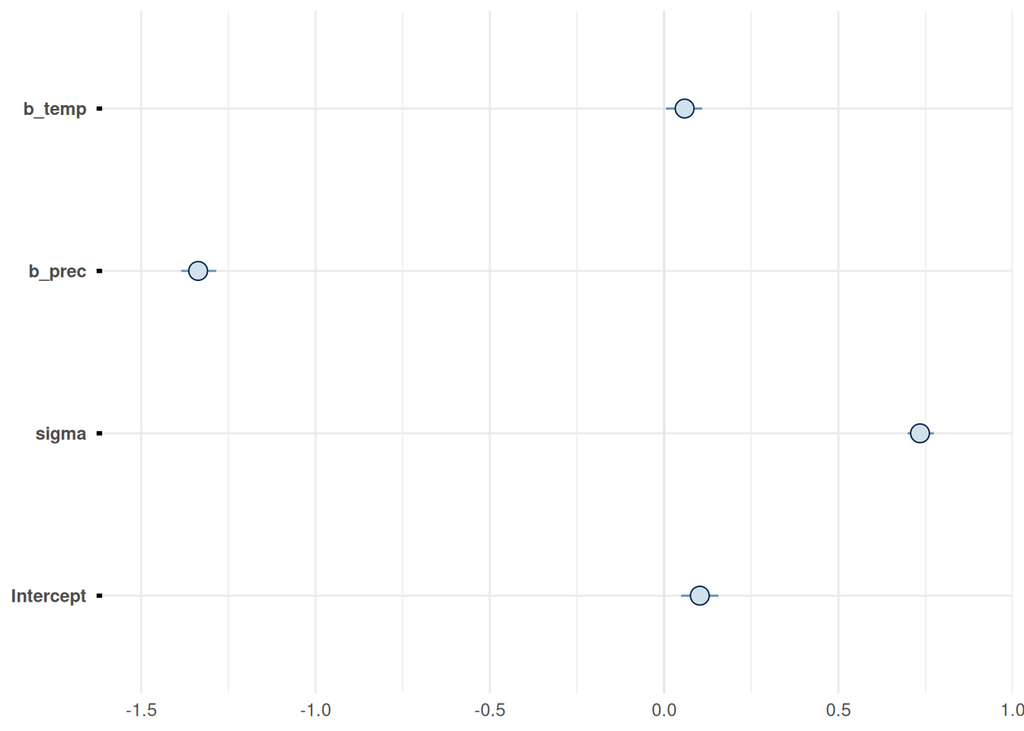

```r
mcmc_intervals(fit_conf_nul, pars = show)
```

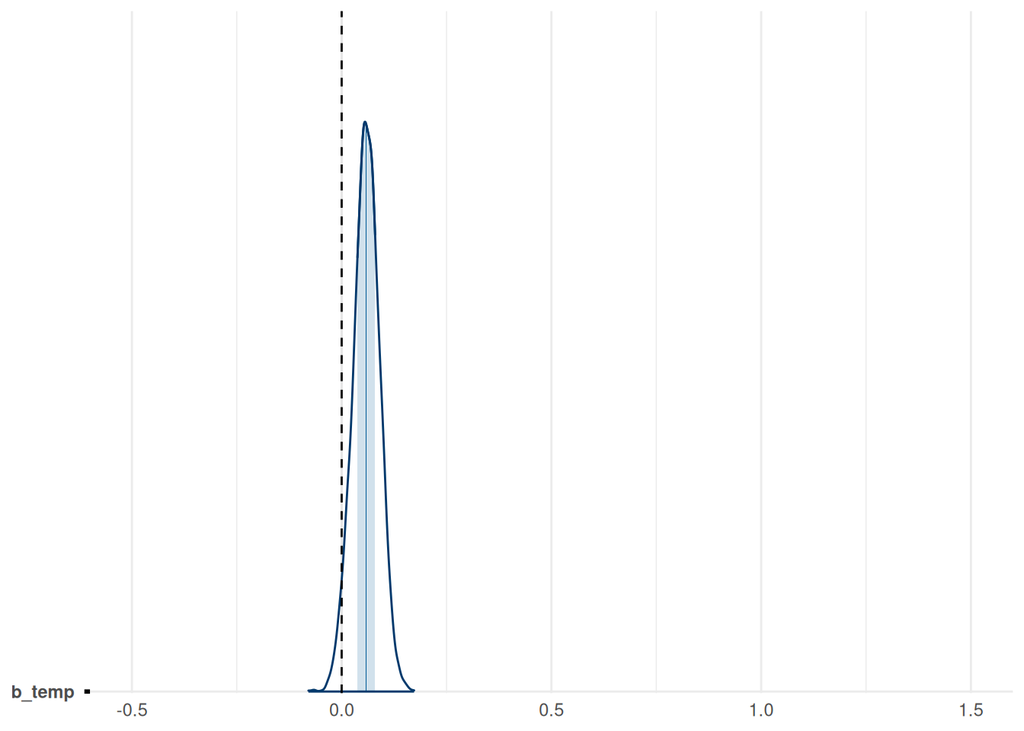

```r
fit_conf_nul |>
  coefplot(0, c(-0.5, 1.5))
```

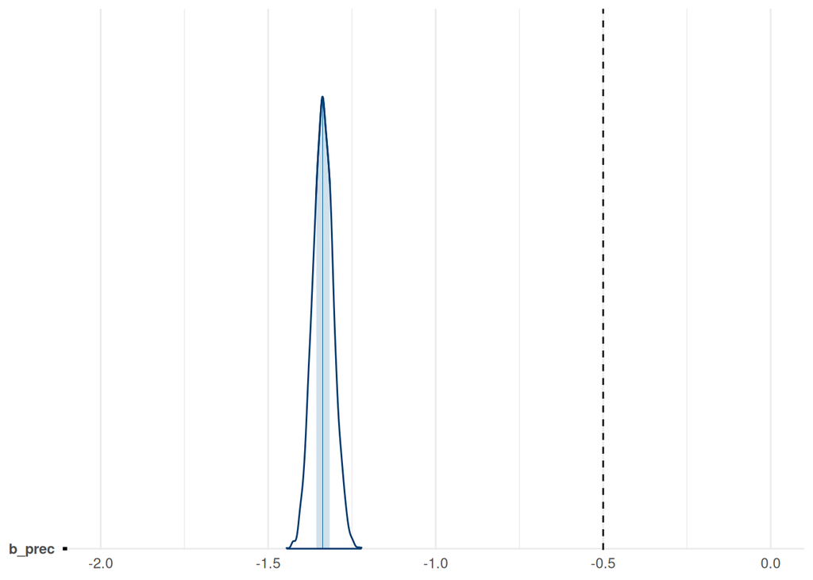

```r
fit_conf_nul |>
  coefplot(-0.5, c(-2, 0), pars = "b_prec")
```

```r
fit_conf_neg <- update(fit_conf_pos,
                       newdata = sim_neg,
                       file = "fits/sim/sim.conf.neg",
                       seed = 295)

fit_conf_neg
```

```
 Family: gaussian
  Links: mu = identity
Formula: FD ~ temp + prec
   Data: sim_neg (Number of observations: 512)
  Draws: 4 chains, each with iter = 2000; warmup = 1000; thin = 1;
         total post-warmup draws = 4000

Regression Coefficients:
          Estimate Est.Error l-95% CI u-95% CI Rhat Bulk_ESS Tail_ESS
Intercept    -0.16      0.04    -0.25    -0.08 1.00     3484     2931
temp         -0.94      0.03    -1.00    -0.88 1.00     3366     3105
prec         -1.34      0.03    -1.40    -1.28 1.00     3655     3167

Further Distributional Parameters:
      Estimate Est.Error l-95% CI u-95% CI Rhat Bulk_ESS Tail_ESS
sigma     0.73      0.02     0.69     0.78 1.00     3730     2831

Draws were sampled using sample(hmc). For each parameter, Bulk_ESS
and Tail_ESS are effective sample size measures, and Rhat is the potential
scale reduction factor on split chains (at convergence, Rhat = 1).
```

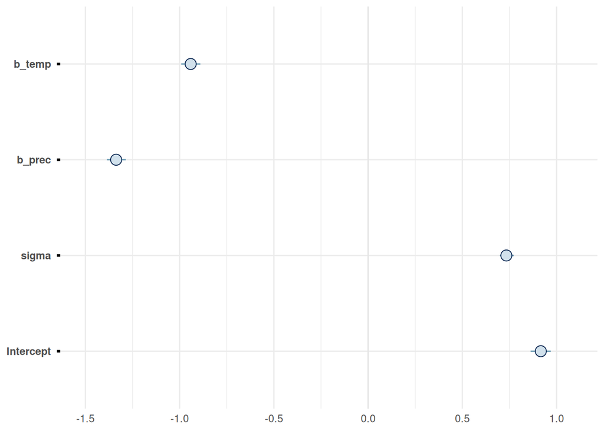

```r
mcmc_intervals(fit_conf_neg, pars = show)
```

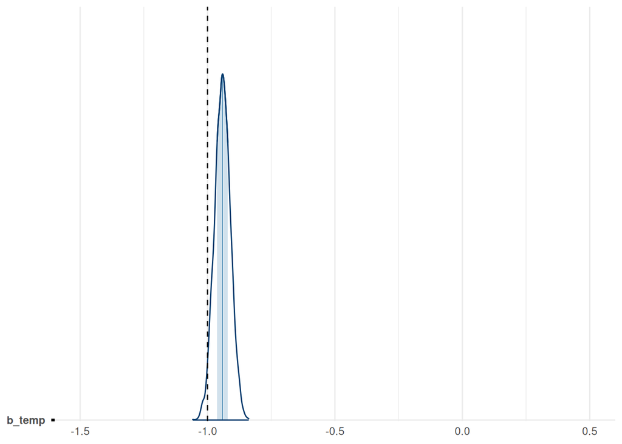

```r
fit_conf_neg |>
  coefplot(-1, c(-1.5, 0.5))
```

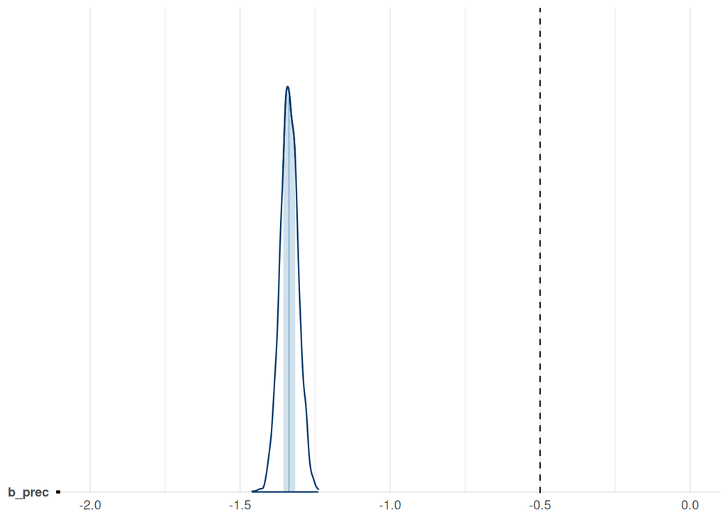

```r
fit_conf_neg |>
  coefplot(-0.5, c(-2, 0), pars = "b_prec")
```

## 5.2 Fixed-effects model

A common solution is to include the cluster variable as fixed effect. In this case, “site” absorbs all time-invariant differences between sites, observed or unobserved.

```r
fit_fix_pos <- brm(FD ~ temp + prec + site,
                   data = sim_pos,
                   prior = prior,
                   file = "fits/sim/sim.fix.pos",
                   seed = 295)

fit_fix_pos
```

```
 Family: gaussian
  Links: mu = identity
Formula: FD ~ temp + prec + site
   Data: sim_pos (Number of observations: 512)
  Draws: 4 chains, each with iter = 2000; warmup = 1000; thin = 1;
         total post-warmup draws = 4000

Regression Coefficients:
          Estimate Est.Error l-95% CI u-95% CI Rhat Bulk_ESS Tail_ESS
Intercept     0.25      0.04     0.17     0.34 1.00     2316     2582
temp          1.00      0.05     0.90     1.10 1.00     1972     2033
prec         -0.46      0.04    -0.54    -0.37 1.00     1619     2352
site1         0.88      0.10     0.67     1.09 1.00     1805     2111
site2        -0.84      0.05    -0.95    -0.75 1.00     1974     2628
site3         1.58      0.07     1.44     1.72 1.00     2037     2942

Further Distributional Parameters:
      Estimate Est.Error l-95% CI u-95% CI Rhat Bulk_ESS Tail_ESS
sigma     0.51      0.02     0.48     0.55 1.00     3400     2639

Draws were sampled using sample(hmc). For each parameter, Bulk_ESS
and Tail_ESS are effective sample size measures, and Rhat is the potential
scale reduction factor on split chains (at convergence, Rhat = 1).
```

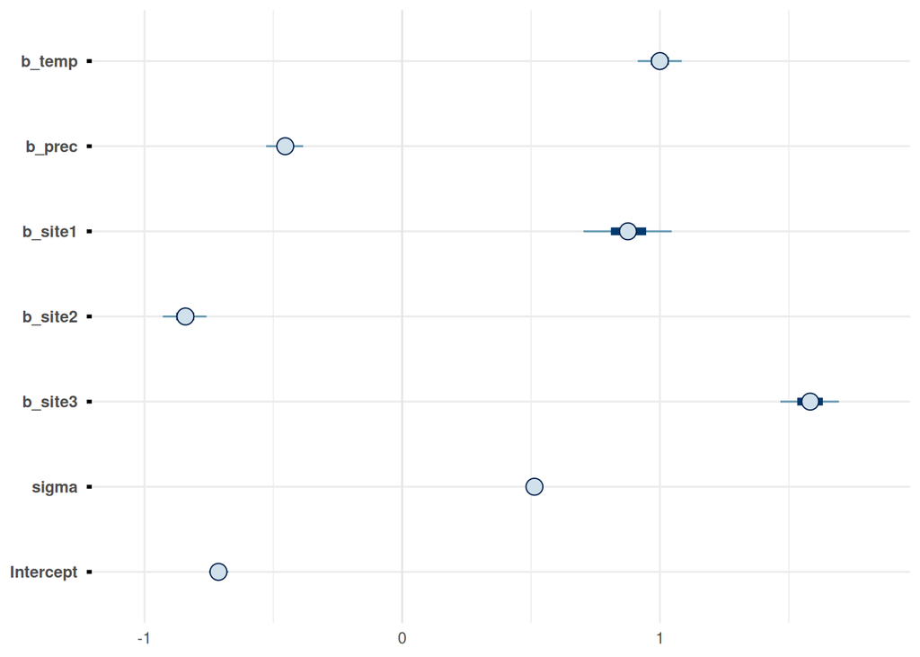

```r
mcmc_intervals(fit_fix_pos, pars = show)
```

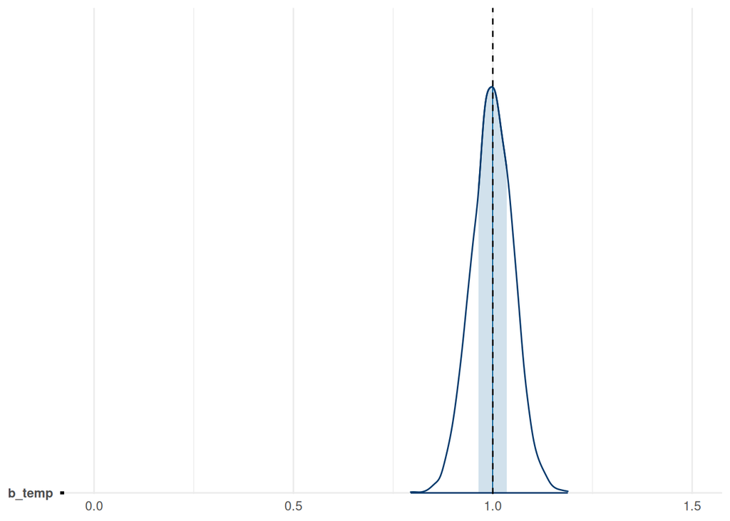

```r
fit_fix_pos |>
  coefplot(1, c(0, 1.5))
```

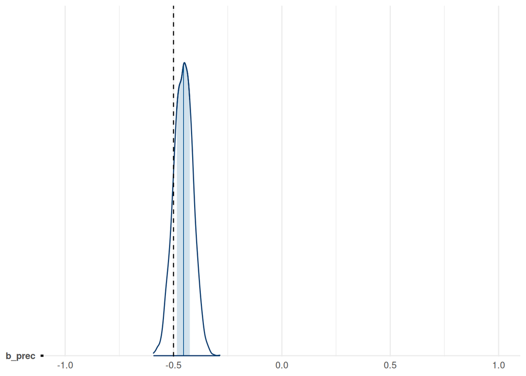

```r
fit_fix_pos |>
  coefplot(-0.5, c(-1, 1), pars = "b_prec")
```

```r
fit_fix_nul <- update(fit_fix_pos,
                      newdata = sim_nul,
                      file = "fits/sim/sim.fix.nul",
                      seed = 295)

fit_fix_nul
```

```
 Family: gaussian
  Links: mu = identity
Formula: FD ~ temp + prec + site
   Data: sim_nul (Number of observations: 512)
  Draws: 4 chains, each with iter = 2000; warmup = 1000; thin = 1;
         total post-warmup draws = 4000

Regression Coefficients:
          Estimate Est.Error l-95% CI u-95% CI Rhat Bulk_ESS Tail_ESS
Intercept     0.25      0.04     0.17     0.34 1.00     2651     2610
temp          0.00      0.05    -0.10     0.11 1.00     2549     2427
prec         -0.46      0.04    -0.54    -0.37 1.00     2287     2491
site1         0.87      0.10     0.67     1.08 1.00     2583     2600
site2        -0.84      0.05    -0.94    -0.74 1.00     2575     2677
site3         1.58      0.07     1.44     1.72 1.00     2345     2604

Further Distributional Parameters:
      Estimate Est.Error l-95% CI u-95% CI Rhat Bulk_ESS Tail_ESS
sigma     0.51      0.02     0.48     0.55 1.00     3158     2359

Draws were sampled using sample(hmc). For each parameter, Bulk_ESS
and Tail_ESS are effective sample size measures, and Rhat is the potential
scale reduction factor on split chains (at convergence, Rhat = 1).
```

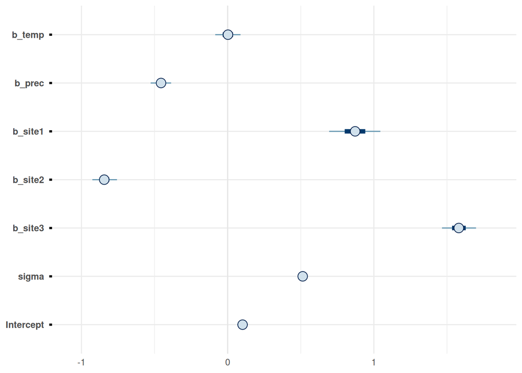

```r
mcmc_intervals(fit_fix_nul, pars = show)
```

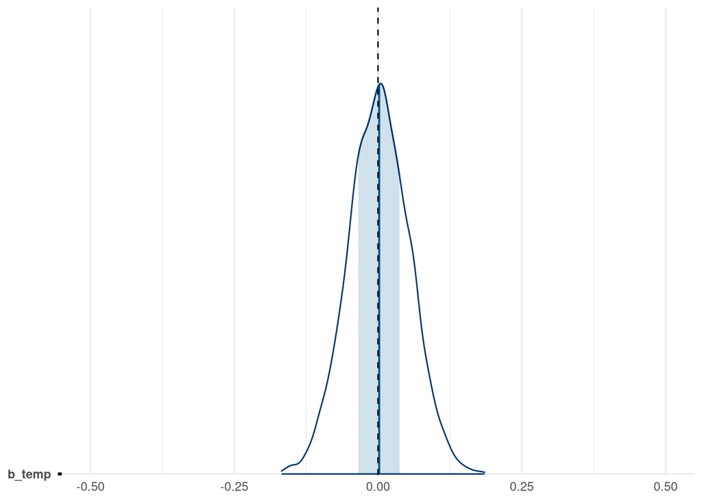

```r
fit_fix_nul |>
  coefplot(0, c(-0.5, 0.5))
```

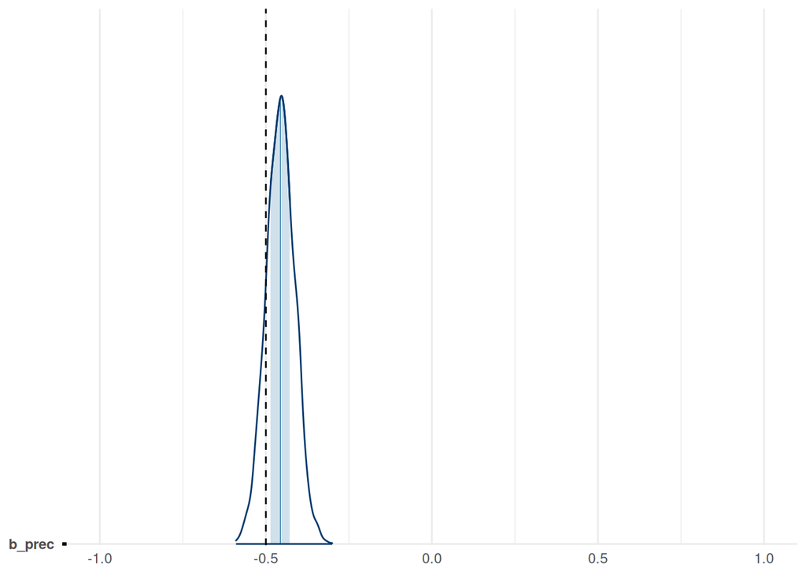

```r
fit_fix_nul |>
  coefplot(-0.5, c(-1, 1), pars = "b_prec")
```

```r
fit_fix_neg <- update(fit_fix_pos,
                      newdata = sim_neg,
                      file = "fits/sim/sim.fix.neg",
                      seed = 295)

fit_fix_neg
```

```
 Family: gaussian
  Links: mu = identity
Formula: FD ~ temp + prec + site
   Data: sim_neg (Number of observations: 512)
  Draws: 4 chains, each with iter = 2000; warmup = 1000; thin = 1;
         total post-warmup draws = 4000

Regression Coefficients:
          Estimate Est.Error l-95% CI u-95% CI Rhat Bulk_ESS Tail_ESS
Intercept     0.26      0.05     0.17     0.34 1.00     2544     2582
temp         -1.00      0.05    -1.10    -0.89 1.00     2304     2419
prec         -0.45      0.04    -0.54    -0.37 1.00     1979     2289
site1         0.87      0.10     0.66     1.08 1.00     2255     2436
site2        -0.84      0.05    -0.95    -0.75 1.00     2504     2800
site3         1.58      0.07     1.44     1.73 1.00     2030     2727

Further Distributional Parameters:
      Estimate Est.Error l-95% CI u-95% CI Rhat Bulk_ESS Tail_ESS
sigma     0.51      0.02     0.48     0.55 1.00     3664     2762

Draws were sampled using sample(hmc). For each parameter, Bulk_ESS
and Tail_ESS are effective sample size measures, and Rhat is the potential
scale reduction factor on split chains (at convergence, Rhat = 1).
```

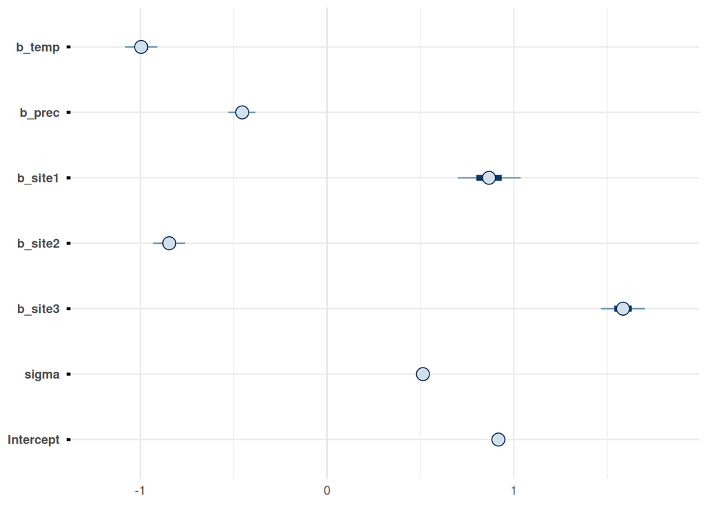

```r
mcmc_intervals(fit_fix_neg, pars = show)
```

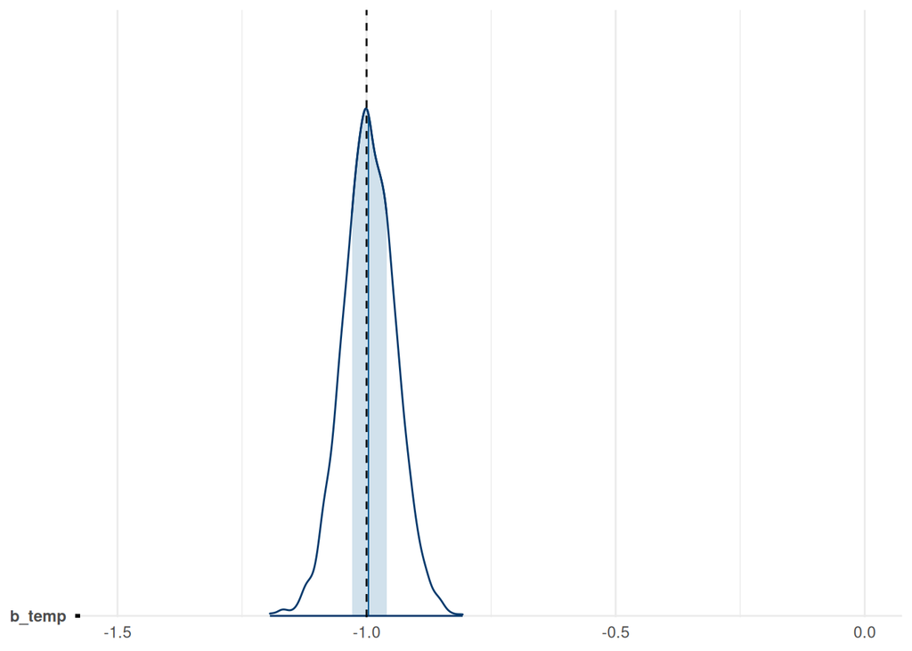

```r
fit_fix_neg |>
  coefplot(-1, c(-1.5, 0))
```

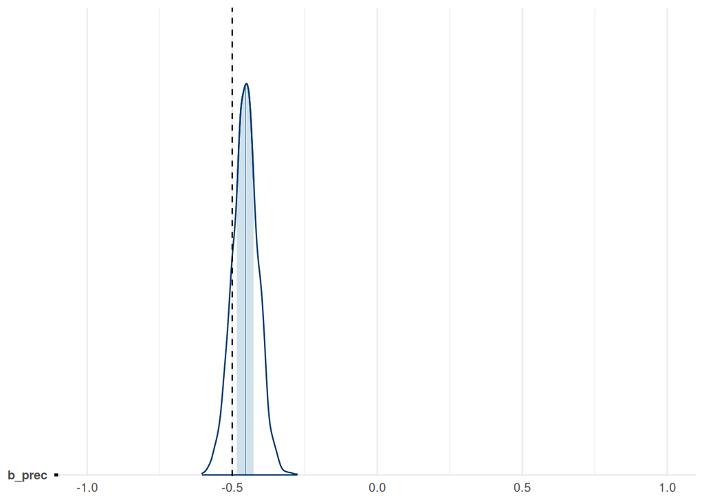

```r
fit_fix_neg |>
  coefplot(-0.5, c(-1, 1), pars = "b_prec")
```

## 5.3 Naive multilevel model

A naive multilevel model without mean centering recovers a single slope which is a mix of the “within” and the “between” effects (Hamaker and Muthén 2020). This could bias the estimate of the effect. The model doesn’t sample great, and there is high uncertainty about the between-site variation (probably because there are only 4 sites), so partial pooling is minimal and the results are close to the fixed-effects models in this case.

```r
prior_re <- c(prior, prior(student_t(3, 0, 0.5), class = "sd", lb = 0))

fit_naive_pos <- brm(FD ~ temp + prec + (1|site),
                     data = sim_pos,
                     prior = prior_re,
                     file = "fits/sim/sim.nai.pos",
                     seed = 295,
                     control = list(adapt_delta = 0.99))

fit_naive_pos
```

```
 Family: gaussian
  Links: mu = identity
Formula: FD ~ temp + prec + (1 | site)
   Data: sim_pos (Number of observations: 512)
  Draws: 4 chains, each with iter = 2000; warmup = 1000; thin = 1;
         total post-warmup draws = 4000

Multilevel Hyperparameters:
~site (Number of levels: 4)
              Estimate Est.Error l-95% CI u-95% CI Rhat Bulk_ESS Tail_ESS
sd(Intercept)     1.31      0.43     0.75     2.38 1.00     1475     2029

Regression Coefficients:
          Estimate Est.Error l-95% CI u-95% CI Rhat Bulk_ESS Tail_ESS
Intercept     0.45      0.49    -0.53     1.42 1.00     1451     1671
temp          1.00      0.05     0.90     1.11 1.00     3031     2374
prec         -0.46      0.04    -0.54    -0.37 1.00     2335     2094

Further Distributional Parameters:
      Estimate Est.Error l-95% CI u-95% CI Rhat Bulk_ESS Tail_ESS
sigma     0.51      0.02     0.48     0.55 1.00     2902     2055

Draws were sampled using sample(hmc). For each parameter, Bulk_ESS
and Tail_ESS are effective sample size measures, and Rhat is the potential
scale reduction factor on split chains (at convergence, Rhat = 1).
```

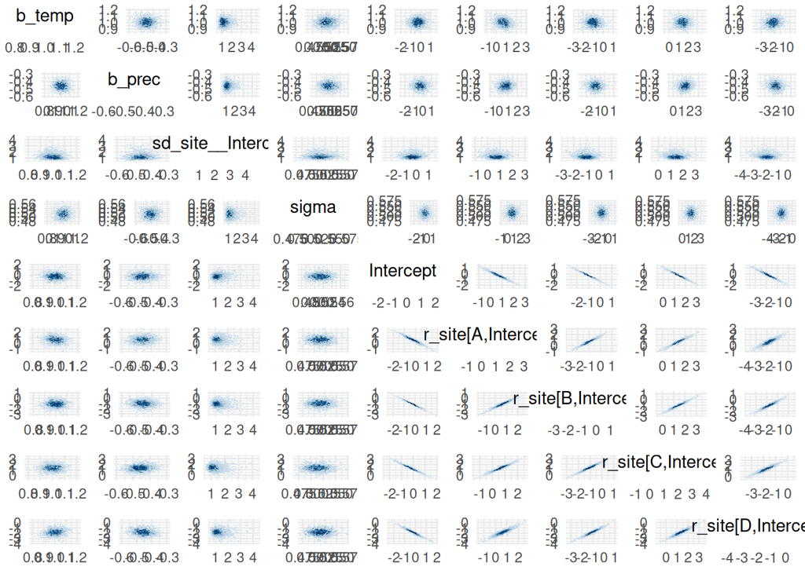

```r
my_mcmc_pairs(fit_naive_pos)
```

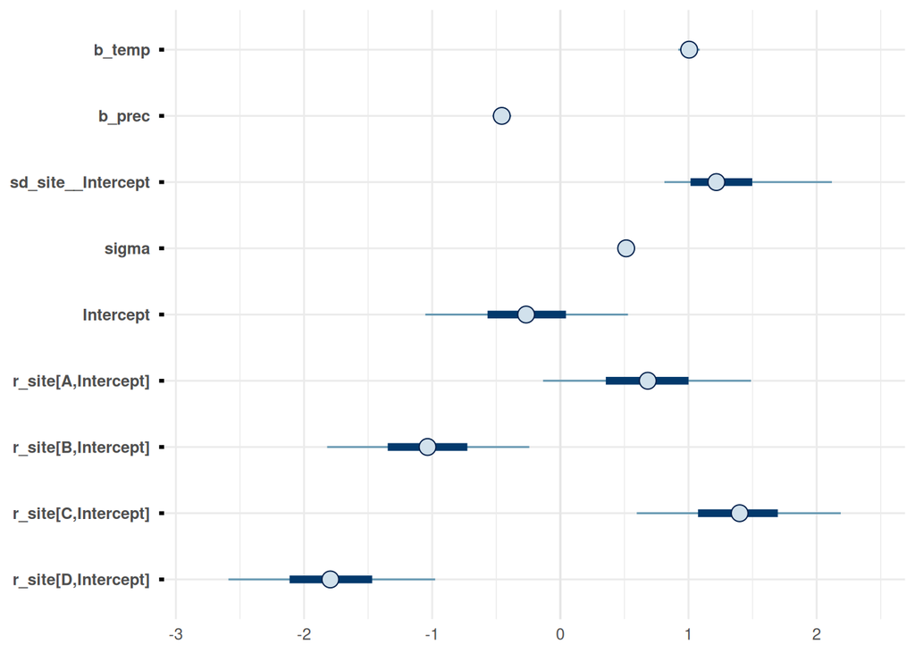

```r
mcmc_intervals(fit_naive_pos, pars = show)
```

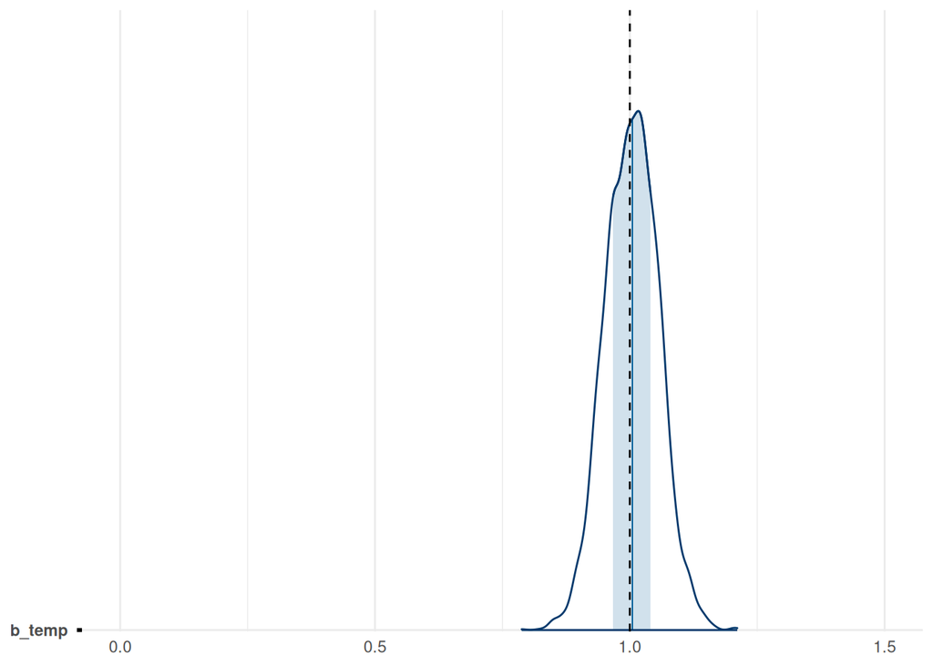

```r
fit_naive_pos |>
  coefplot(1, c(0, 1.5))
```